# Lab1AnalisisPCA

### Cantidad de baños completos

```
##
##   0   1   2   3
##   9 650 768  33
```

```
##
##           0           1           2           3
## 0.006164384 0.445205479 0.526027397 0.022602740
```

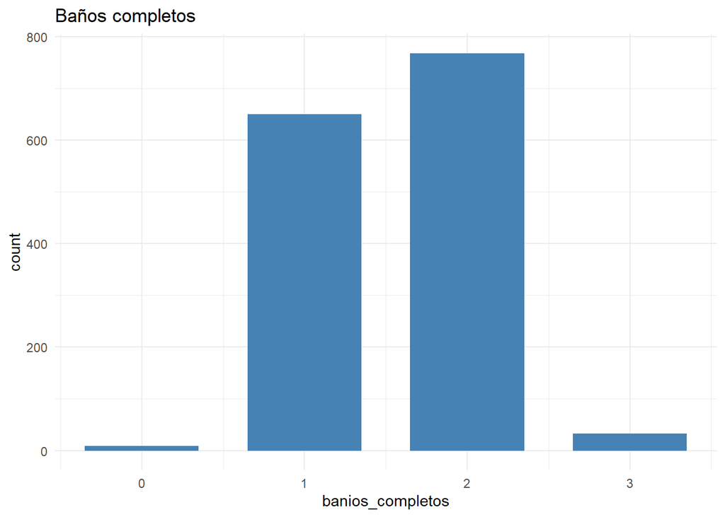

En este caso se evalúa la cantidad de baños completos en toda la casa, no únicamente en el sótano, y de la misma manera se cuenta con las opciones desde que no se cuente con baños completos hasta contar con un máximo de 3. En la mayoría de casas se cuenta con 2 baños completos, sin tomar en cuenta los baños del sótano.

### Cantidad de medios baños

```
##
##   0   1   2
## 913 535  12
```

```
##
##           0           1           2
## 0.625342466 0.366438356 0.008219178
```

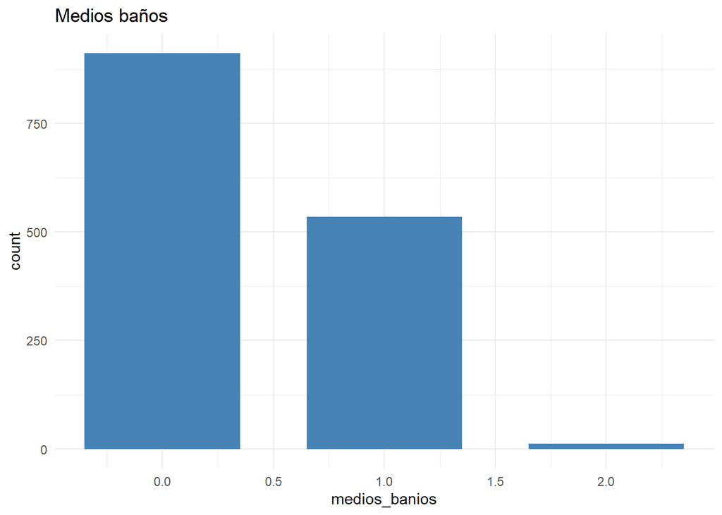

En este caso se evalúa la cantidad de medios baños en toda la casa y se cuenta con las opciones desde que no se cuente con medios baños hasta contar con un máximo de 2.La mayoría de casas no cuenta con medios baños.

### Cantidad de chimeneas

```
##
##   0   1   2   3
## 690 650 115   5
```

```
##
##           0           1           2           3
## 0.472602740 0.445205479 0.078767123 0.003424658
```

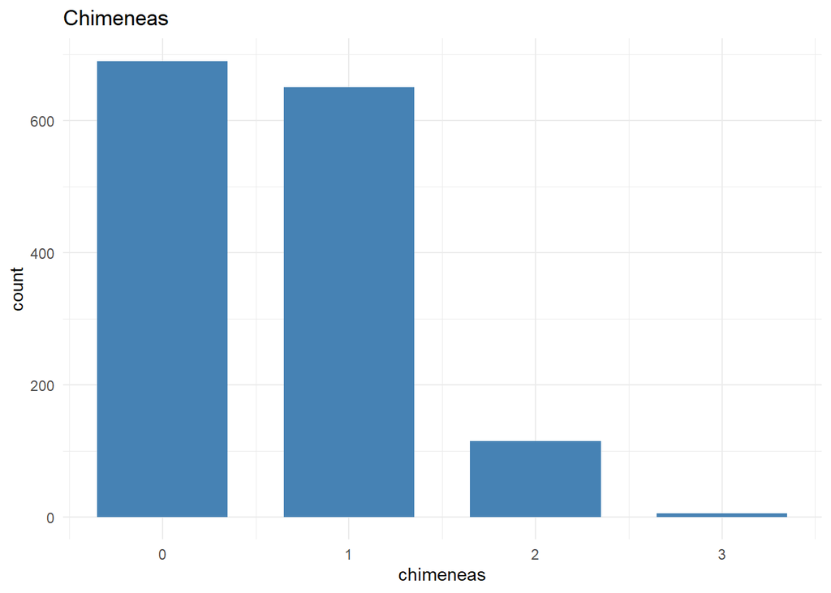

### Proximidad

```
##
## Artery  Feedr   Norm   PosA   PosN   RRAe   RRAn   RRNe   RRNn
##     48     81   1260      8     19     11     26      2      5
```

```
##
##      Artery       Feedr        Norm        PosA        PosN        RRAe
## 0.032876712 0.055479452 0.863013699 0.005479452 0.013013699 0.007534247
##        RRAn        RRNe        RRNn
## 0.017808219 0.001369863 0.003424658
```

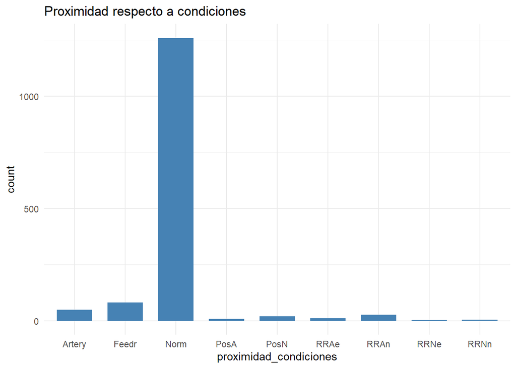

En cuanto a la proximidad, se tiene la siguiente distribución: Artery: Adyacente a una calle arterial Feedr: Adyacente a una calle de alimentación Norm: Normal RRNn: A 200’ del ferrocarril norte-sur RRAn: Junto al ferrocarril norte-sur PosN: Cerca de un parque, cinturón verde, etc. PosA: Junto a una característica externa positiva RRNe: A 200’ del ferrocarril este-oeste RRAe: Adyacente al ferrocarril este-oeste

Entre todas las posibles proximidades, puede observarse que la proximidad más común es la normal.

### Tipo de vivienda

```
##
## 1.5Fin 1.5Unf 1Story 2.5Fin 2.5Unf 2Story SFoyer   SLvl
##    154     14    726      8     11    445     37     65
```

```
##
##      1.5Fin      1.5Unf      1Story      2.5Fin      2.5Unf      2Story
## 0.105479452 0.009589041 0.497260274 0.005479452 0.007534247 0.304794521
##      SFoyer        SLvl
## 0.025342466 0.044520548
```

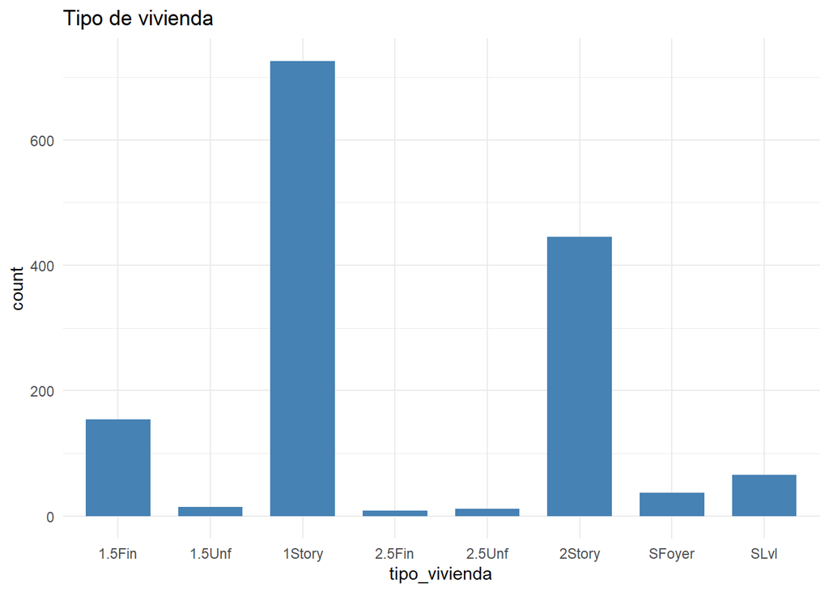

En este caso se habla del estilo de vivienda, puede haber viviendas de un piso, casas en las que el segundo piso sea considerado como medio y que este se encuentre terminado o no terminado, de la misma con dos pisos. También se cuenta con casas de vestíbulo dividido y con casas de piso dividido. Puede observarse cómo es que el tipo de vivienda más común es el de un solo nivel, seguido por las casas de 2 niveles.

### Estilo de vivienda

```
##
##   1Fam 2fmCon Duplex  Twnhs TwnhsE
##   1220     31     52     43    114
```

```
##
##       1Fam     2fmCon     Duplex      Twnhs     TwnhsE
## 0.83561644 0.02123288 0.03561644 0.02945205 0.07808219
```

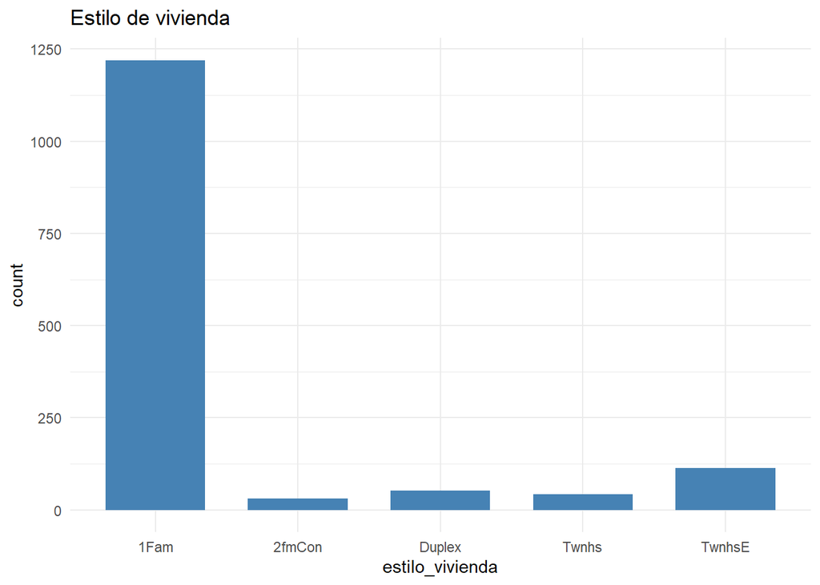

En el estilo de vivienda se estudia la cantidad de familias que ocupan la casa. De la misma manera, puede observarse que los estilos de viviendas más comunes son para una sola familia.

### Materiales y acabados generales

```
##
##   1   2   3   4   5   6   7   8   9  10
##   2   3  20 116 397 374 319 168  43  18
```

```
##
##           1           2           3           4           5           6
## 0.001369863 0.002054795 0.013698630 0.079452055 0.271917808 0.256164384
##           7           8           9          10
## 0.218493151 0.115068493 0.029452055 0.012328767
```

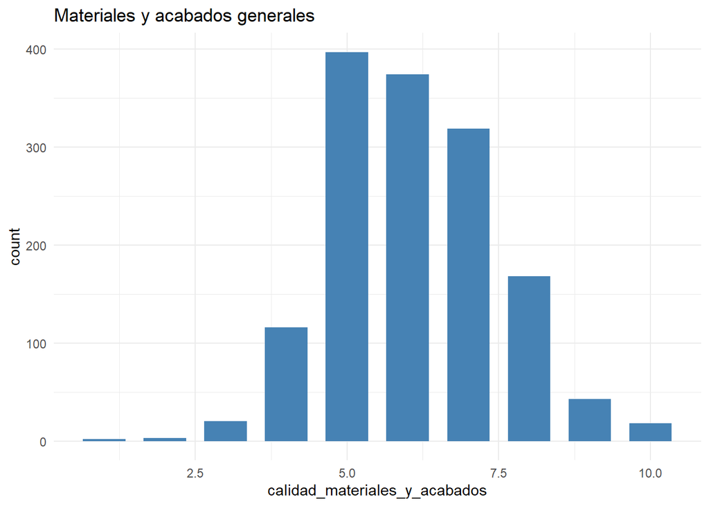

```
##
##   1   2   3   4   5   6   7   8   9
##   1   5  25  57 821 252 205  72  22
```

```
##
##            1            2            3            4            5            6
## 0.0006849315 0.0034246575 0.0171232877 0.0390410959 0.5623287671 0.1726027397
##            7            8            9
## 0.1404109589 0.0493150685 0.0150684932
```

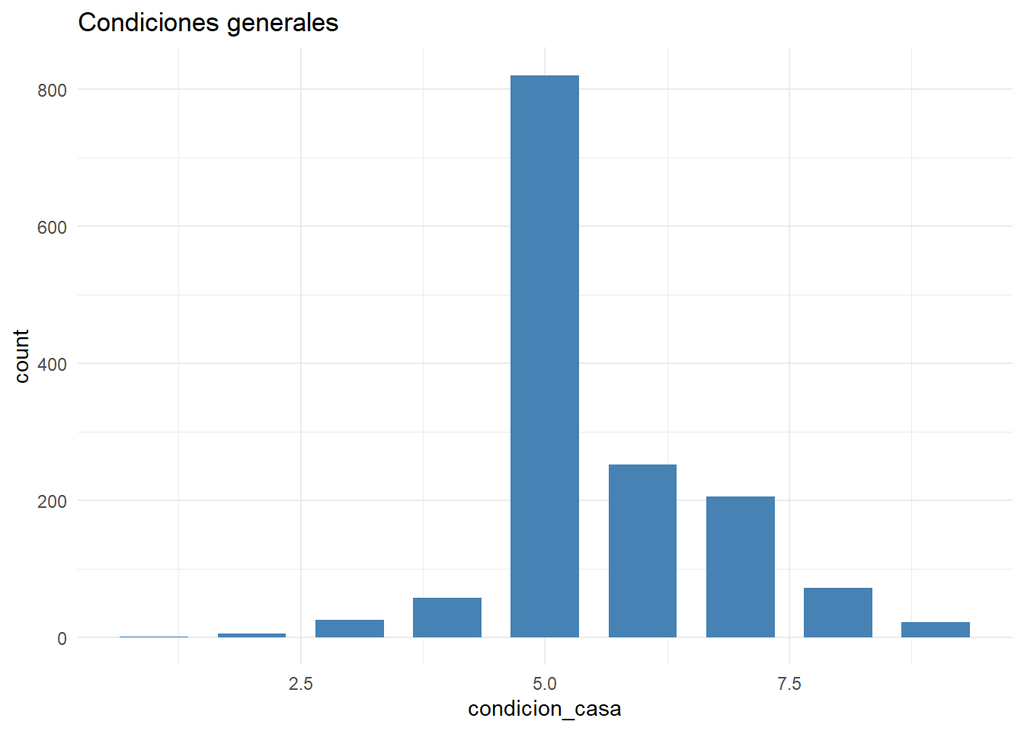

### Condicion del sotano

```
##
##   Fa   Gd   Po   TA
##   45   65    2 1311
```

```
##
##          Fa          Gd          Po          TA
## 0.031623331 0.045678145 0.001405481 0.921293043
```

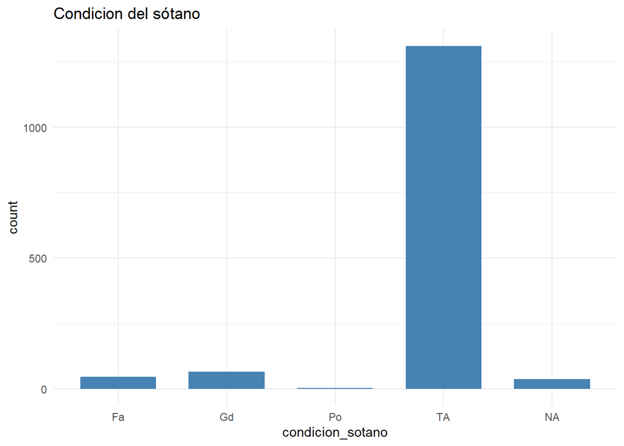

En las condiciones del sótano se cuenta con las siguientes posibilidades: Ex: Excelente Gd: Bueno TA: Típico Fa: Justo Po: Pobre NA: No hay sotano

Podemos observar que la mayoría de los sótanos se encuentra en una condición típica, con un poco de humedad, seguido por una buena condición.

### Exposicion del sotano

```
##
##  Av  Gd  Mn  No
## 221 134 114 953
```

```
##
##         Av         Gd         Mn         No
## 0.15541491 0.09423347 0.08016878 0.67018284
```

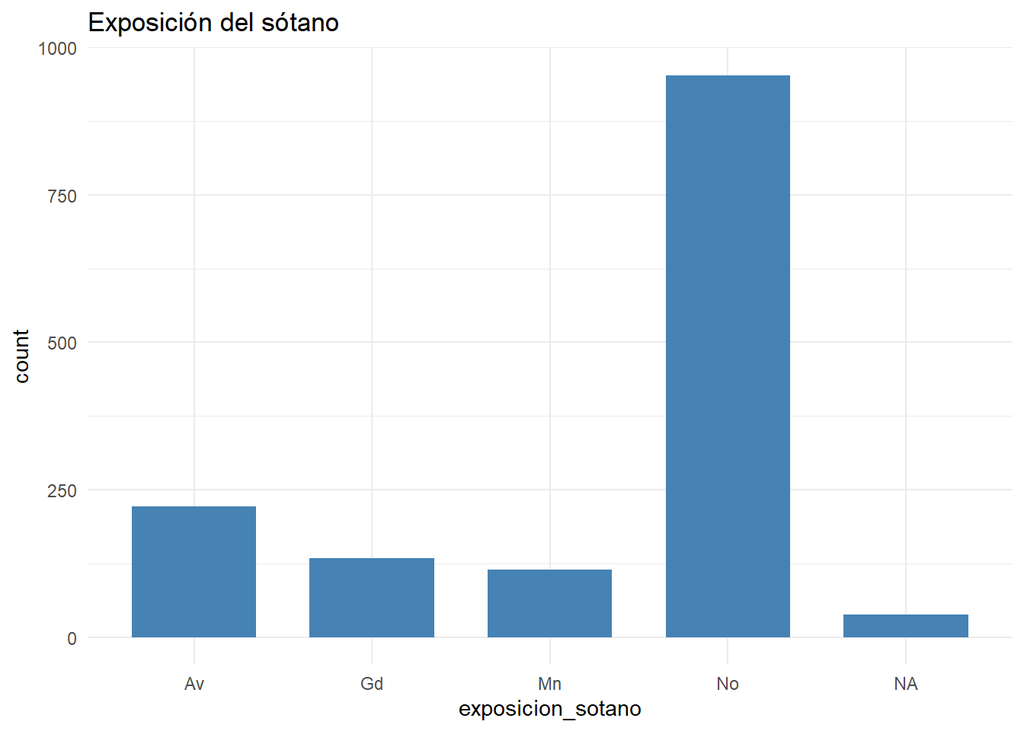

En este caso, se representa los muros del sótano a nivel de jardín o si existe un espacio suficiente para tener una salida directa del sótado al jardín, dividiéndose de la siguiente manera: Gd: buena exposicicon Av: exposicion promedio Mn: mínima exposicion No: no hay exposición NA: no hay sótano

En este caso la mayoría no cuenta con espacio suficiente para tener una puerta directa hacia el jardín.

### Tipo de calefaccion

```
##
## Floor  GasA  GasW  Grav  OthW  Wall
##     1  1428    18     7     2     4
```

```
##
##        Floor         GasA         GasW         Grav         OthW         Wall
## 0.0006849315 0.9780821918 0.0123287671 0.0047945205 0.0013698630 0.0027397260
```

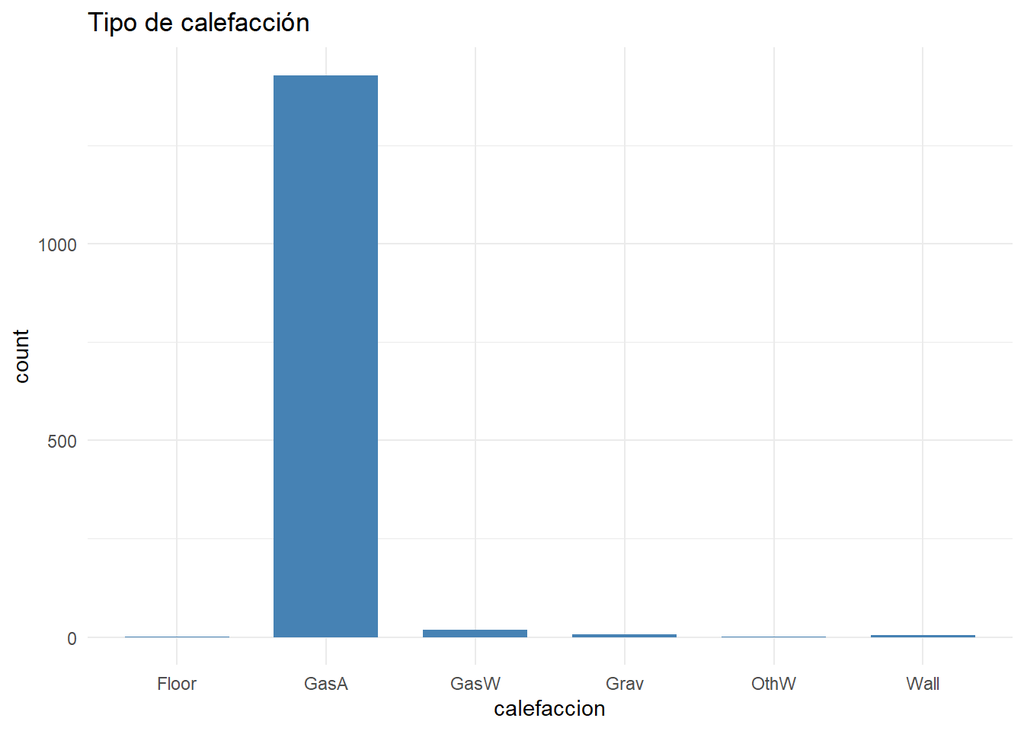

Los tipos de calefacción se dividen en los siguientes: Floor: horno de piso GasA: horno de aire caliente forzado a gas GasW: calefaccion de agua caliente o vapor a gas Grav: horno de gravedad OthW: calefacción por agua caliente o vapor que no sea de gas Wall: Horno de pared

Puede observarse que el tipo de calefacción más común es el horno de aire caliente forzado a gas.

### Tipo de sistema electrico

```
##
## FuseA FuseF FuseP   Mix SBrkr
##    94    27     3     1  1334
```

```
##
##       FuseA       FuseF       FuseP         Mix       SBrkr
## 0.064427690 0.018505826 0.002056203 0.000685401 0.914324880
```

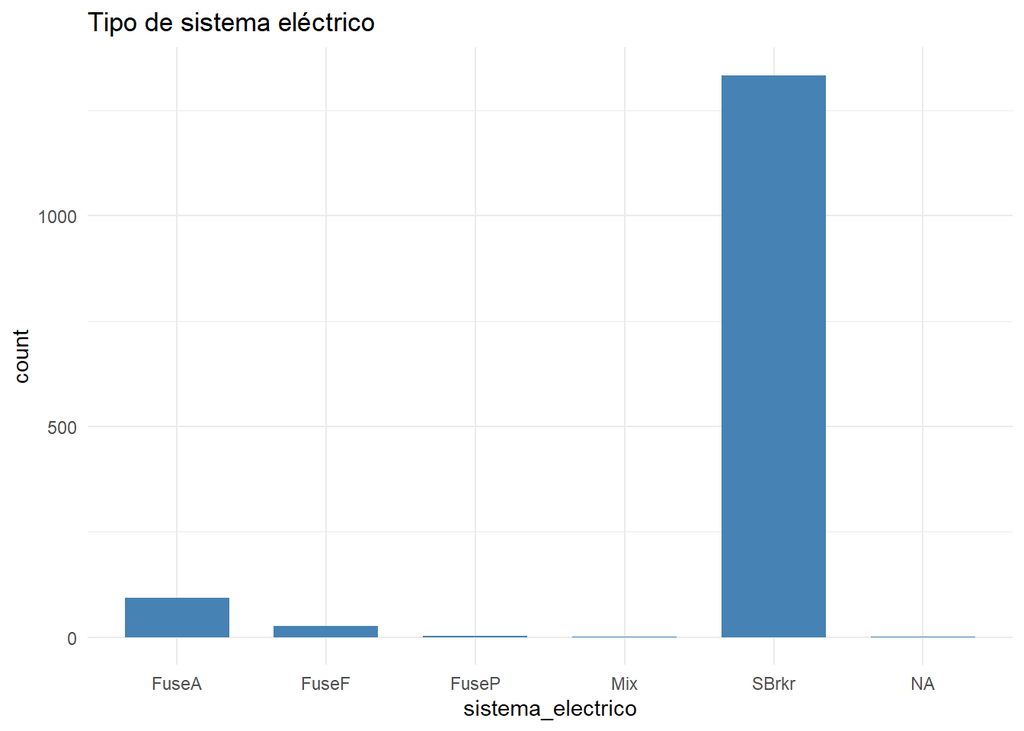

En la mayoría de hogares se cuenta con us sistemaeléctrico de disyuntores estándar y Romex

### Cantidad de cocinas sobre el suelo (sin contar cocinas en los sotanos)

```
##
##    0    1    2    3
##    1 1392   65    2
```

```
##
##            0            1            2            3
## 0.0006849315 0.9534246575 0.0445205479 0.0013698630
```

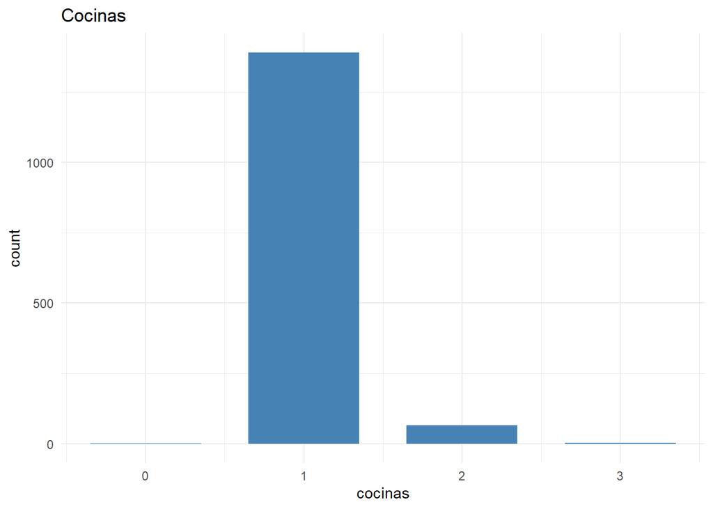

### Calidad de las cocinas

```
##
##  Ex  Fa  Gd  TA
## 100  39 586 735
```

```
##
##         Ex         Fa         Gd         TA
## 0.06849315 0.02671233 0.40136986 0.50342466
```

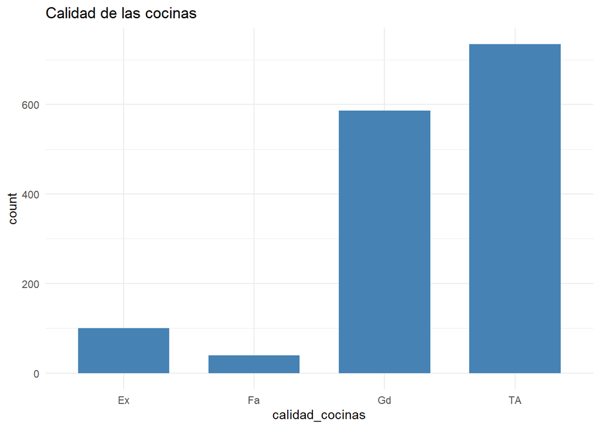

La calidad de las cocinas se divide en lo siguiente: Ex: Excelente Gd: Buena TA: Típica Fa: justo Po: pobre En este gráfico puede observarse que la calidad de las cocinas es típica o promedio.

### Tipo de venta

```
##
##   COD   Con ConLD ConLI ConLw   CWD   New   Oth    WD
##    43     2     9     5     5     4   122     3  1267
```

```
##
##         COD         Con       ConLD       ConLI       ConLw         CWD
## 0.029452055 0.001369863 0.006164384 0.003424658 0.003424658 0.002739726
##         New         Oth          WD
## 0.083561644 0.002054795 0.867808219
```

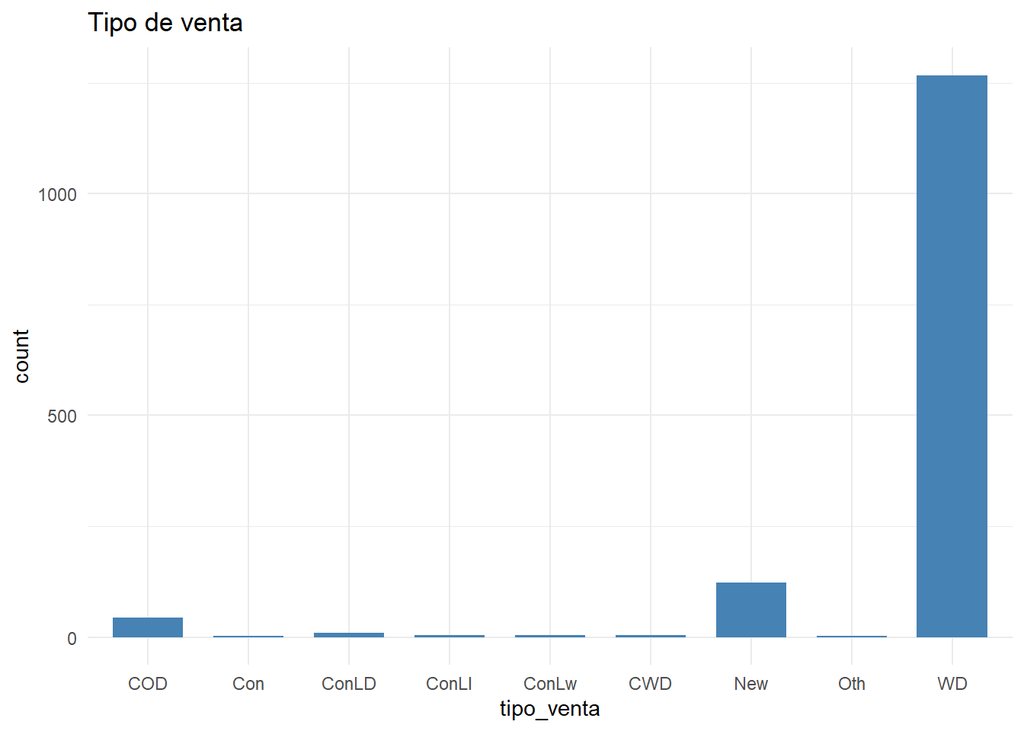

Entre los tipos de ventas se encuentran los siguientes: WD: Escritura de garantía - convencional CWD: Escritura de garantía - dinero en efectivo VWD: Escritura de garantía - Préstamo VA New: Casa recién costruida y vendida COD: Oficial de la corte o estado Con: Contrato 15% de pago inicial en términos regulares ConLw: Contrato de bajo pago inicial y bajo interés ConLI: Contrato de bajo interés ConLD: Contrato de baja cuota inicial Oth: otro

Puede observarse que el tipo de venta más común es el convencional con una escritura de garantía.

### Condicion de venta

```
##
## Abnorml AdjLand  Alloca  Family  Normal Partial
##     101       4      12      20    1198     125
```

```
##
##     Abnorml     AdjLand      Alloca      Family      Normal     Partial
## 0.069178082 0.002739726 0.008219178 0.013698630 0.820547945 0.085616438
```

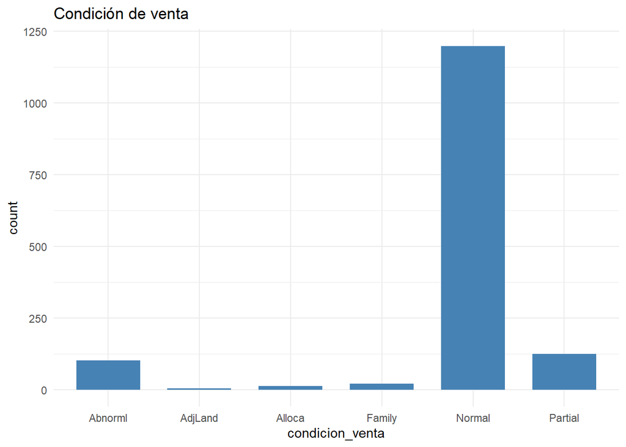

Entre las condiciones de venta se encuentran las siguientes: Normal: venta normal Abnorml: venta normal - comercio, ejecución hipotecaria, venta al descubierto AdjLand: compra de terreno contiguo Alloca: adjudicación - dos propiedades vinculadas con escrituras separadas, normalmente un condominio con una unidad de garaje Family: venta entre miembros de la familia Partial: la vivienda no estaba terminada cuando se evaluó por última vez (asociada a viviendas nuevas) Por último, puede observarse que la condición de venta más común es una venta normal.

## PCA

Debido a la gran cantidad de variables y datos el procesamiento y estudio de datos se vuelve algo tedioso y complicado, por lo tanto, se propone realizar pruebas para evaluar la viabilidad de un análisis de componentes principales.

```
## [1] -2.414164e-39
```

El determinante es un valor sumamente pequeño muy próximo a 0, por lo tanto indica que existe multicolinealidad

Debido a que el determinante es extremadamente cercano a 0, el sistema es computacionalmente singular y por lo tanto no se puede invertir para realizar la prueba, esto se da debido a una dependencia lieneal entre las columnas, por lo que existen variables fuertemente relacionadas, para ejemplificar mejor esto, se procederá a utilizar una prueba de esfericidad de Barlett en donde se tiene lo siguiente: Ho: La matriz de correlaciones es igual a la matriz identidad Ha: la matriz de correlaciones es diferente a la matriz identidad

```
## R was not square, finding R from data
```

```
## $chisq
## [1] 56775.11
##
## $p.value
## [1] 0
##
## $df
## [1] 666
```

Debido a que el valor p es 0 (valor teórico) esto implica que es menor a la signficancia (0.05), por lo tanto se rechaza la hipótesis nula y se acepta que la matriz de correlaciones es diferente a la matiz identidad, lo que implica que si parece ser conveniente realizar un PCA para disminuir mis variables.

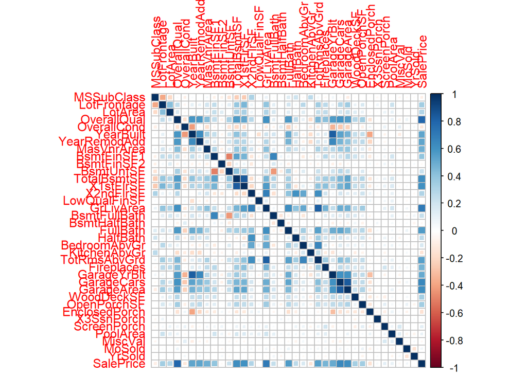

Para observar rapidamente la correlaciones entre variables se hace un gráfico en donde la intensidad del color indica que tan interelacionados están los componentes, es evidente que existen varias variables que muestran estar fuertemente relacionados entre sí, por lo que tambien indica que un análisis de componentes es factible.

Para comenzar formalmente el análisis se deben de normalizar los datos para poder escalarlos.

```
## Standard deviations (1, .., p=37):
##  [1] 2.866924e+00 1.777216e+00 1.645007e+00 1.429262e+00 1.237694e+00
##  [6] 1.113365e+00 1.102149e+00 1.067827e+00 1.057423e+00 1.048759e+00
## [11] 1.036298e+00 1.015273e+00 9.902729e-01 9.614591e-01 9.459412e-01
## [16] 9.236737e-01 8.899043e-01 8.740893e-01 8.658084e-01 8.289132e-01
## [21] 8.057633e-01 7.777012e-01 7.277481e-01 6.872100e-01 6.298046e-01
## [26] 6.196741e-01 5.676609e-01 5.214276e-01 5.033932e-01 4.535874e-01
## [31] 4.198754e-01 3.888722e-01 3.751419e-01 3.441058e-01 3.193638e-01
## [36] 2.493275e-15 7.480721e-16
##
## Rotation (n x k) = (37 x 37):
##                        PC1           PC2           PC3         PC4          PC5
## MSSubClass    -0.019082664 -1.777334e-01  0.2109920090 -0.32827796  0.250287087
## LotFrontage    0.155750374  5.991915e-07 -0.2885921723  0.18713755 -0.001759512
## LotArea        0.115338836  1.107478e-02 -0.2861440049  0.05300381 -0.013021048
## OverallQual    0.288056491  1.773443e-02  0.0929217915 -0.01581851 -0.141098204
## OverallCond   -0.094100191 -6.118495e-02 -0.1557280479 -0.03615488 -0.395687226
## YearBuilt      0.224567270  1.988882e-01  0.2973788201 -0.09557247 -0.002014765
## YearRemodAdd   0.201411090  1.116747e-01  0.2396852250 -0.06535930 -0.235426217
## MasVnrArea     0.188054701  4.492579e-03 -0.0059709509 -0.06758056  0.084787703
## BsmtFinSF1     0.136655894  2.510873e-01 -0.2765999515 -0.33738579  0.140220262
## BsmtFinSF2    -0.016477730  6.856915e-02 -0.1732066828 -0.06876505 -0.066025506
## BsmtUnfSF      0.108556241 -6.849966e-02  0.1835602399  0.54294922 -0.092544072
## TotalBsmtSF    0.247467305  2.189693e-01 -0.1665913053  0.16961174  0.030488705
## X1stFlrSF      0.245740017  1.660615e-01 -0.2204276495  0.21128275  0.112785872
## X2ndFlrSF      0.114792805 -4.586150e-01  0.0450447377 -0.22034846 -0.064430645
## LowQualFinSF  -0.003788493 -1.000293e-01 -0.0849333729  0.01911019 -0.073041848
## GrLivArea      0.277025015 -2.695372e-01 -0.1315605910 -0.02720815  0.023409226
## BsmtFullBath   0.078084541  2.541795e-01 -0.2180182887 -0.35909234  0.174529079
## BsmtHalfBath  -0.021557257 -7.153644e-03 -0.0572764970 -0.03873606 -0.138598997
## FullBath       0.243243102 -1.335325e-01  0.1537549875  0.06097072  0.089965364
## HalfBath       0.104809641 -2.519757e-01  0.0930372726 -0.31207517 -0.170838007
## BedroomAbvGr   0.096698348 -3.674667e-01 -0.1273727642  0.08832916  0.079617475
## KitchenAbvGr  -0.017429454 -1.507870e-01 -0.0295883597  0.06832064  0.579611295
## TotRmsAbvGrd   0.224963829 -3.301309e-01 -0.1071732183  0.03671514  0.114104636
## Fireplaces     0.167561704 -5.408121e-02 -0.2018984557 -0.06557452 -0.175675525
## GarageYrBlt    0.223346465  1.582873e-01  0.3216029141 -0.06443785 -0.002948439
## GarageCars     0.268373855  3.634903e-02  0.1142889809  0.05480195  0.116314675
## GarageArea     0.263247252  8.019048e-02  0.0408578575  0.06250514  0.116228759
## WoodDeckSF     0.130166819  4.043273e-02 -0.0071847601 -0.13570379 -0.085972742
```

[output cut: 260 more lines]

```
## TotRmsAbvGrd   0.0227769415  3.768970e-16 -3.231837e-16
## Fireplaces     0.0220491441 -2.519825e-16  4.743085e-17
## GarageYrBlt    0.3801049964 -2.533580e-16  3.657181e-17
## GarageCars     0.0324269516  2.407770e-17  1.565076e-16
## GarageArea    -0.1497638558 -2.908321e-18 -9.392709e-17
## WoodDeckSF    -0.0064384914 -1.685499e-16  9.877549e-17
## OpenPorchSF   -0.0004549458  1.360988e-16  7.315591e-17
## EnclosedPorch -0.0660348940 -7.840109e-18  6.638849e-17
## X3SsnPorch    -0.0108620214 -1.841032e-16 -1.462749e-16
## ScreenPorch   -0.0205575317 -8.275843e-18  1.496648e-16
## PoolArea       0.0273898834  7.151395e-17  6.544364e-17
## MiscVal       -0.0028796053 -5.323075e-17 -1.146793e-16
## MoSold        -0.0041085429  3.579200e-18 -9.463311e-17
## YrSold        -0.0092119822  2.304258e-16  1.002922e-16
## SalePrice      0.1750916446 -2.867999e-17  3.488204e-17
```

```
## Importance of components:
##                           PC1     PC2     PC3     PC4    PC5    PC6     PC7
## Standard deviation     2.8669 1.77722 1.64501 1.42926 1.2377 1.1134 1.10215
## Proportion of Variance 0.2221 0.08536 0.07314 0.05521 0.0414 0.0335 0.03283
## Cumulative Proportion  0.2221 0.30751 0.38064 0.43585 0.4773 0.5108 0.54359
##                            PC8     PC9    PC10    PC11    PC12   PC13    PC14
## Standard deviation     1.06783 1.05742 1.04876 1.03630 1.01527 0.9903 0.96146
## Proportion of Variance 0.03082 0.03022 0.02973 0.02902 0.02786 0.0265 0.02498
## Cumulative Proportion  0.57441 0.60463 0.63435 0.66338 0.69124 0.7177 0.74272
##                           PC15    PC16   PC17    PC18    PC19    PC20    PC21
## Standard deviation     0.94594 0.92367 0.8899 0.87409 0.86581 0.82891 0.80576
## Proportion of Variance 0.02418 0.02306 0.0214 0.02065 0.02026 0.01857 0.01755
## Cumulative Proportion  0.76691 0.78997 0.8114 0.83202 0.85228 0.87085 0.88840
##                           PC22    PC23    PC24    PC25    PC26    PC27    PC28
## Standard deviation     0.77770 0.72775 0.68721 0.62980 0.61967 0.56766 0.52143
## Proportion of Variance 0.01635 0.01431 0.01276 0.01072 0.01038 0.00871 0.00735
## Cumulative Proportion  0.90474 0.91906 0.93182 0.94254 0.95292 0.96163 0.96898
##                           PC29    PC30    PC31    PC32   PC33   PC34    PC35
## Standard deviation     0.50339 0.45359 0.41988 0.38887 0.3751 0.3441 0.31936
## Proportion of Variance 0.00685 0.00556 0.00476 0.00409 0.0038 0.0032 0.00276
## Cumulative Proportion  0.97583 0.98139 0.98615 0.99024 0.9940 0.9972 1.00000
##                             PC36      PC37
## Standard deviation     2.493e-15 7.481e-16
## Proportion of Variance 0.000e+00 0.000e+00
## Cumulative Proportion  1.000e+00 1.000e+00
```

en el resúmen observando la proporción acumulativa podemos determinar hasta que componentes tenemos una explicación razonable. En el componente 17 (reduciendo hasta 20) se obtiene una explicación de la varianza de hasta el 80% mientras que en el componente 22 (reduciendo hasta 15) se explica hasta el 90%

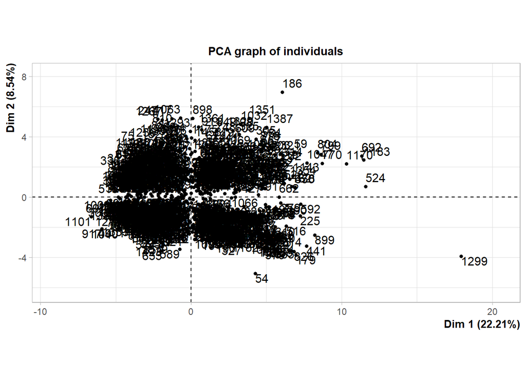

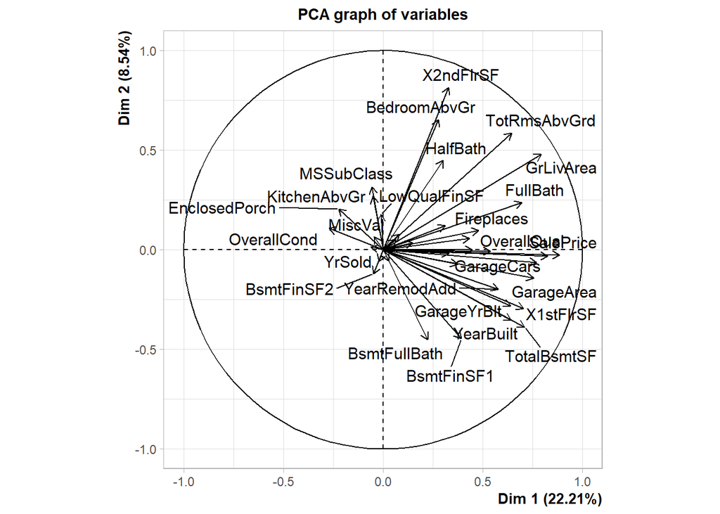

```
##
## Call:
## PCA(X = h, scale.unit = T, ncp = ncol(h))
##
##
## Eigenvalues
##                        Dim.1   Dim.2   Dim.3   Dim.4   Dim.5   Dim.6   Dim.7
## Variance               8.219   3.158   2.706   2.043   1.532   1.240   1.215
## % of var.             22.214   8.536   7.314   5.521   4.140   3.350   3.283
## Cumulative % of var.  22.214  30.751  38.064  43.585  47.726  51.076  54.359
##                        Dim.8   Dim.9  Dim.10  Dim.11  Dim.12  Dim.13  Dim.14
## Variance               1.140   1.118   1.100   1.074   1.031   0.981   0.924
## % of var.              3.082   3.022   2.973   2.902   2.786   2.650   2.498
## Cumulative % of var.  57.441  60.463  63.435  66.338  69.124  71.774  74.272
##                       Dim.15  Dim.16  Dim.17  Dim.18  Dim.19  Dim.20  Dim.21
## Variance               0.895   0.853   0.792   0.764   0.750   0.687   0.649
## % of var.              2.418   2.306   2.140   2.065   2.026   1.857   1.755
## Cumulative % of var.  76.691  78.997  81.137  83.202  85.228  87.085  88.840
##                       Dim.22  Dim.23  Dim.24  Dim.25  Dim.26  Dim.27  Dim.28
## Variance               0.605   0.530   0.472   0.397   0.384   0.322   0.272
## % of var.              1.635   1.431   1.276   1.072   1.038   0.871   0.735
## Cumulative % of var.  90.474  91.906  93.182  94.254  95.292  96.163  96.898
##                       Dim.29  Dim.30  Dim.31  Dim.32  Dim.33  Dim.34  Dim.35
## Variance               0.253   0.206   0.176   0.151   0.141   0.118   0.102
## % of var.              0.685   0.556   0.476   0.409   0.380   0.320   0.276
## Cumulative % of var.  97.583  98.139  98.615  99.024  99.404  99.724 100.000
##                       Dim.36  Dim.37
## Variance               0.000   0.000
## % of var.              0.000   0.000
## Cumulative % of var. 100.000 100.000
##
## Individuals (the 10 first)
##                   Dist    Dim.1    ctr   cos2    Dim.2    ctr   cos2    Dim.3
## 1             |  4.022 |  1.301  0.018  0.105 |  0.492  0.007  0.015 | -1.266
## 2             |  5.742 | -0.277  0.001  0.002 | -0.970  0.027  0.029 |  1.230
## 3             |  3.435 |  1.545  0.026  0.202 |  0.381  0.004  0.012 | -1.119
## 4             |  6.092 | -0.611  0.004  0.010 |  1.134  0.036  0.035 |  0.738
## 5             |  5.602 |  4.351  0.205  0.603 |  1.433  0.058  0.065 | -0.338
## 6             | 12.315 | -1.060  0.012  0.007 | -1.743  0.086  0.020 | -0.253
## 7             |  4.812 |  3.358  0.122  0.487 | -2.396  0.162  0.248 |  0.616
```

[output cut: 23 more lines]

```
## YearRemodAdd  |  0.577  4.057  0.333 | -0.198  1.247  0.039 | -0.394  5.745
## MasVnrArea    |  0.539  3.536  0.291 | -0.008  0.002  0.000 |  0.010  0.004
## BsmtFinSF1    |  0.392  1.867  0.153 | -0.446  6.304  0.199 |  0.455  7.651
## BsmtFinSF2    | -0.047  0.027  0.002 | -0.122  0.470  0.015 |  0.285  3.000
##                 cos2
## MSSubClass     0.120 |
## LotFrontage    0.225 |
## LotArea        0.222 |
## OverallQual    0.023 |
## OverallCond    0.066 |
## YearBuilt      0.239 |
## YearRemodAdd   0.155 |
## MasVnrArea     0.000 |
## BsmtFinSF1     0.207 |
## BsmtFinSF2     0.081 |
```

En el gráfico de variables se puede ver la representación de las mismas en las primeras dos dimensiones y en que regiones pueden ser agrupadas por una fuerte correlación. También se observa en el output los valores propios y representación en cada dimensión que se verá mejor en los gráficos a continuación.

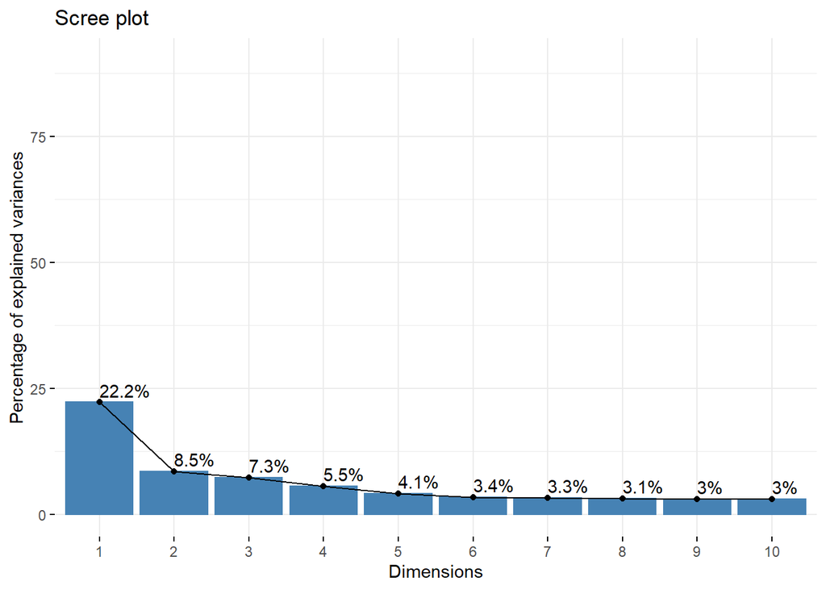

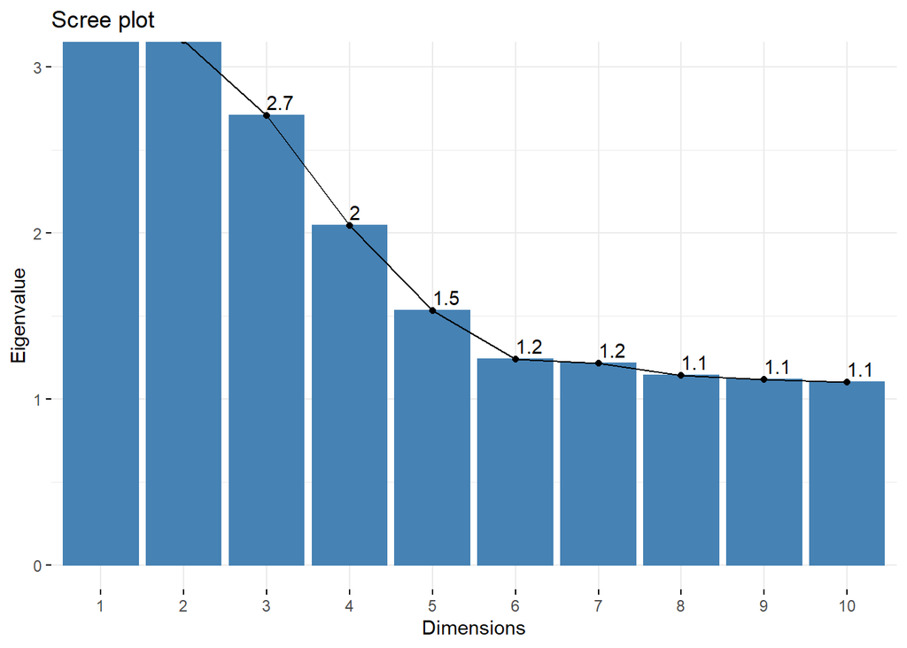

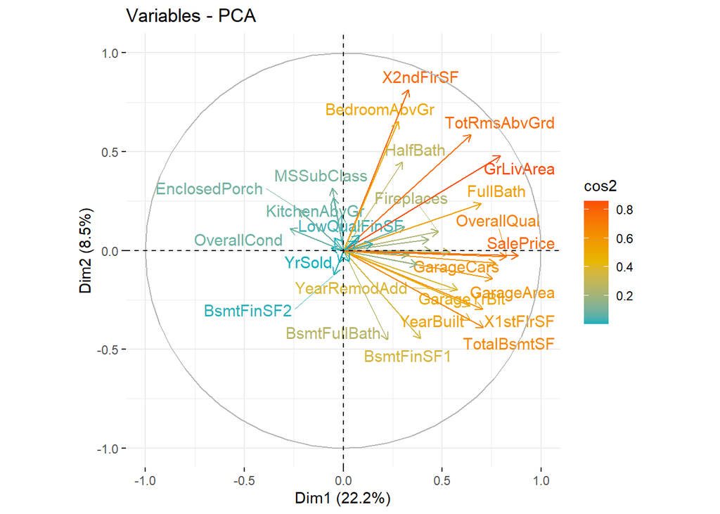

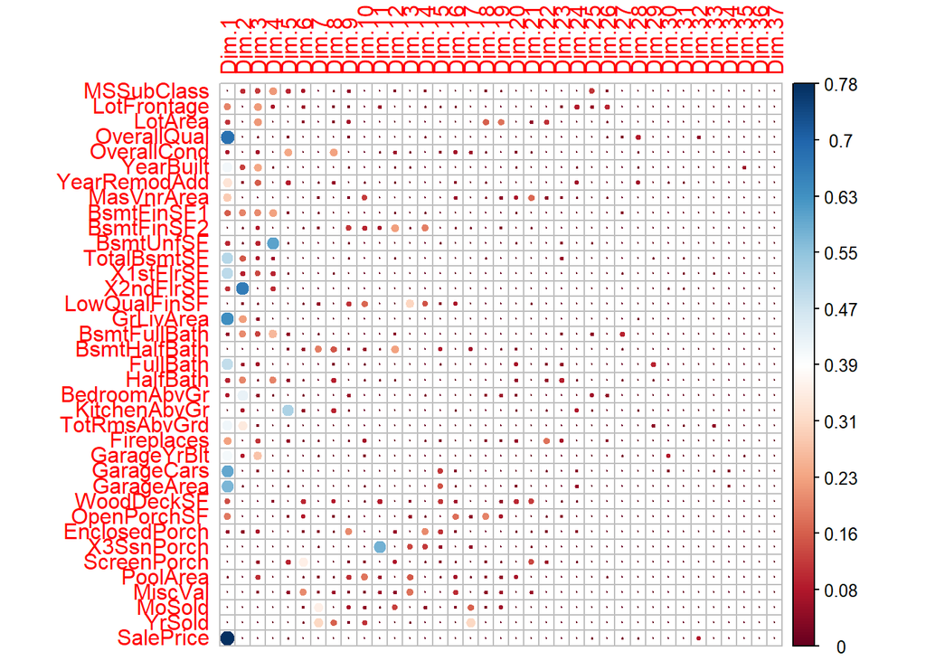

En este gráfico se puede observar la contribución de cada variable en cada dimensión. Ya habiendo observado la contribución acumulativa y ahora el gráfico se puede concluir que se puede explicar suficiente varianza utilizando 17 dimensiones ya que se llega al 80% y las demás dimensiones contribuyen con muy poco.

## Representación de cada dimensión

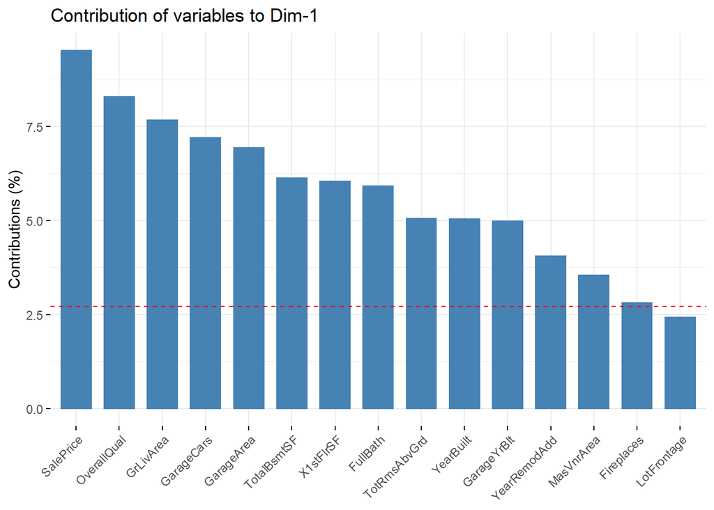

Las variables de esta dimensión que aportan significativamente a la varianza y están correlacionadas se pueden englobar en lujos o comodidades de un hogar en relación a precio cosas particulares de un hogar. Es decir, entre más calidad o más grande el área, el garaje, remodelación etc, más se aporta a la característica de ser más lujoso.

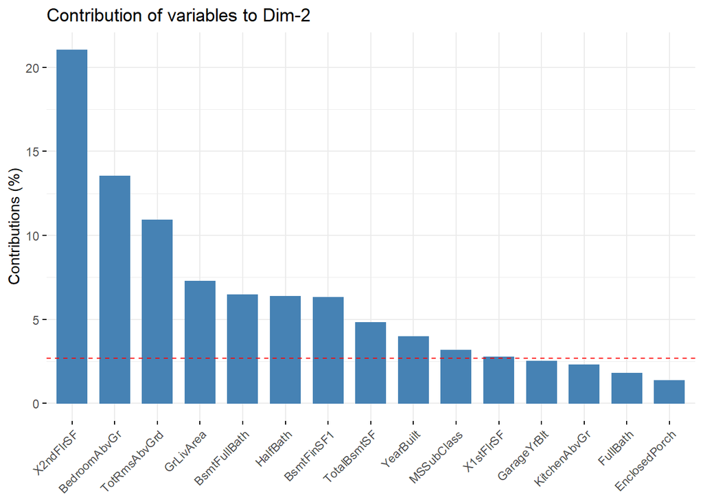

En la segunda dimensión se puede observar que las variables que se encuentran sobre el límite se encuentran relacionadas de alguna manera al tamaño del hogar en base a características de construcción, siendo X2ndFlrSF en tamaño del segundo piso, BedrroomAbv es la cantidad de cuartos, tambien está la variable de área, tamaño del balo, sótano etc.

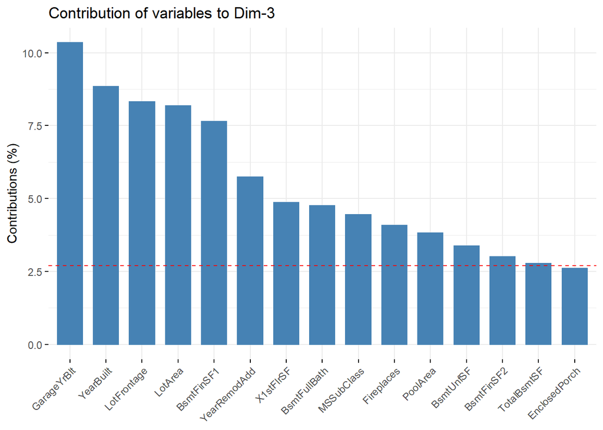

En está dimensión se encuentran varias variables que contienen información referente a remodelación de varios aspectos de la casa y las otras hacia partes particulares de un hogar, como chimeneas, piscina, baños etc.

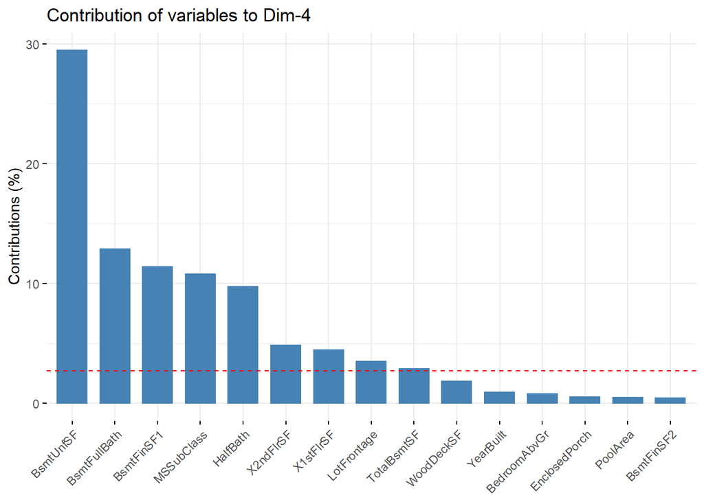

En la dimensión 4 se puede observar que las variables que se encuentran sobre el límite (en su mayoría) tienen información sobre el sótano y su área (SF) en relación al tipo de clase que se puede encontrar en las casas.

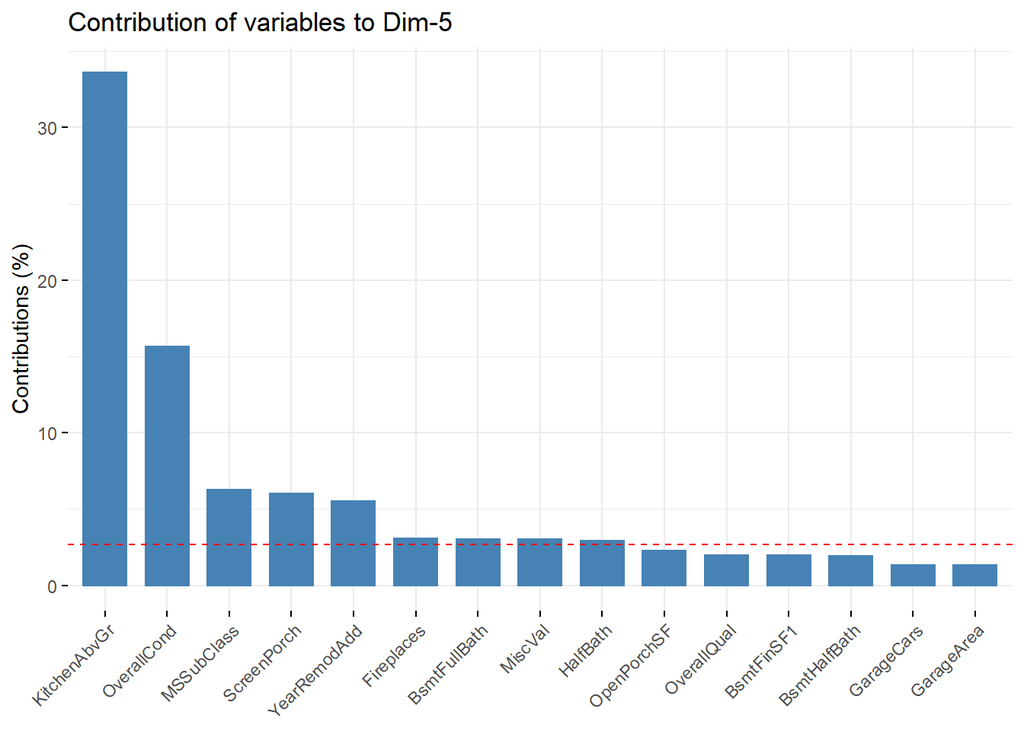

En la 5ta dimensión se pueden observar que hay 4 variables que dificilmente se encuentran sobre el límite para ser significativos MiscVal hace referancia a características miscelaneas que no son cubiertas por la información general de la casa, las demás características se pueden unificar por ser “extras” de una casa por lo general, como el tamaño de la cocina, fogatas, pórticos y si estos tienden a existir cuando se notifica una remodelación.

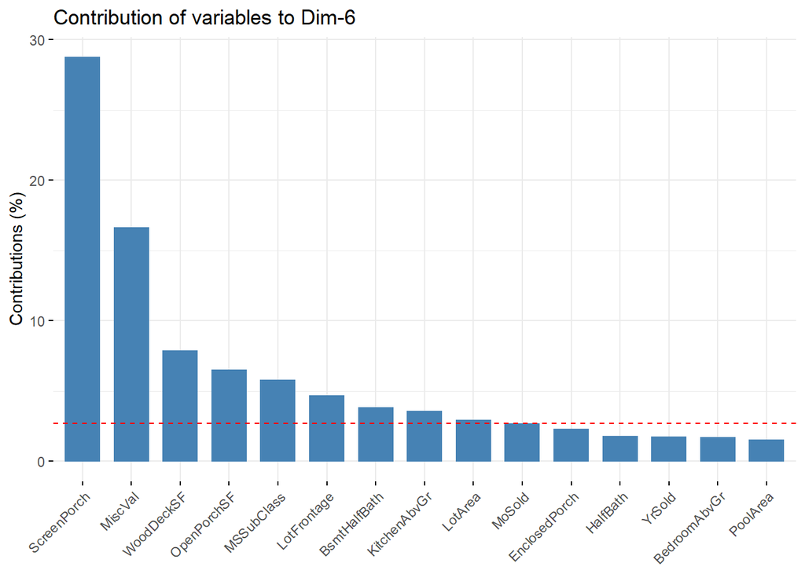

Las 9 variables que se encuentran sobre el límite de la dimensión 6 son un poco más variadas, 5 de ellas se pueden relacionar por teenr información sobre el pórtico o deck y su tamaño, tomando en cuenta tambien el tamaño del lote completo. Adicionalmente se encuentran otras como la variable de miscelaneos (el precio neto de features extras), la clase, el tamaño de la cocina y baños medios en el sótano, que de cierta manera también se corelacionan por tamaño de características particulares no escenciales de un hogar.

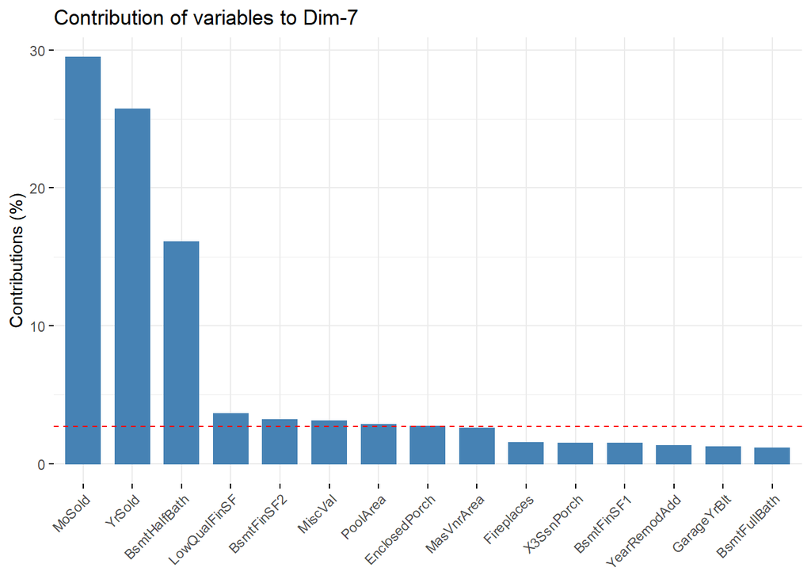

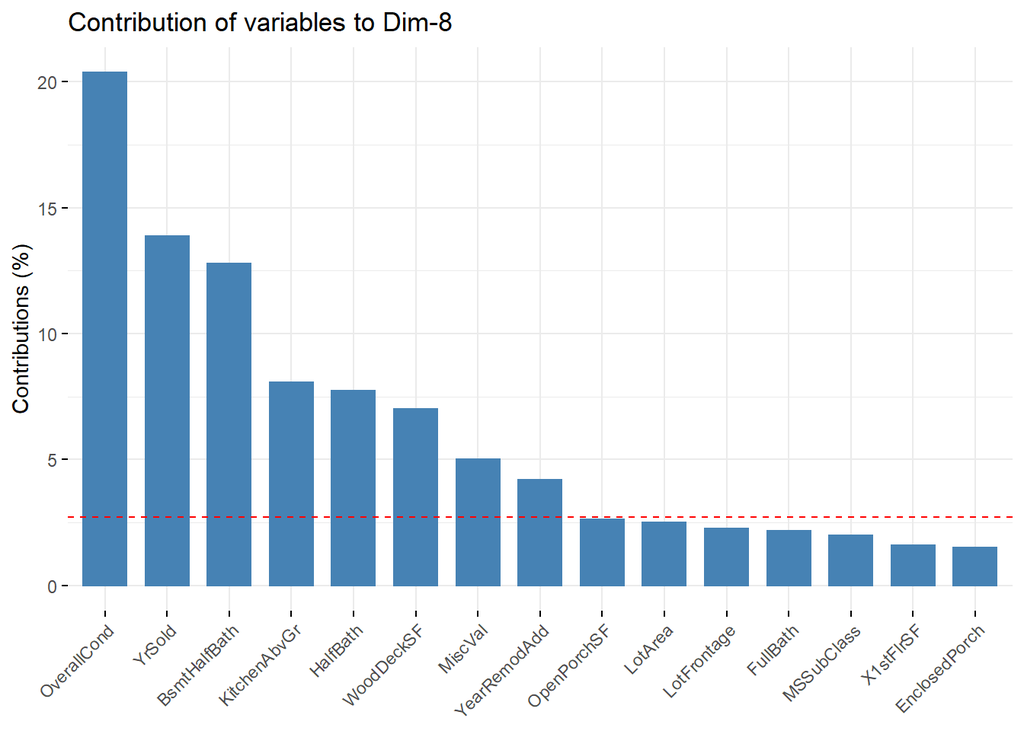

En la dimensión 8 se encuentran 8 variables sobre el límite. Las variables como el año, presencia de medios baños, tamaño de la cocina, decks e incluso la remodelación se pueden unificar por la mejora de calidad (overallCond) de un hogar luego de que ha sido remodelada.

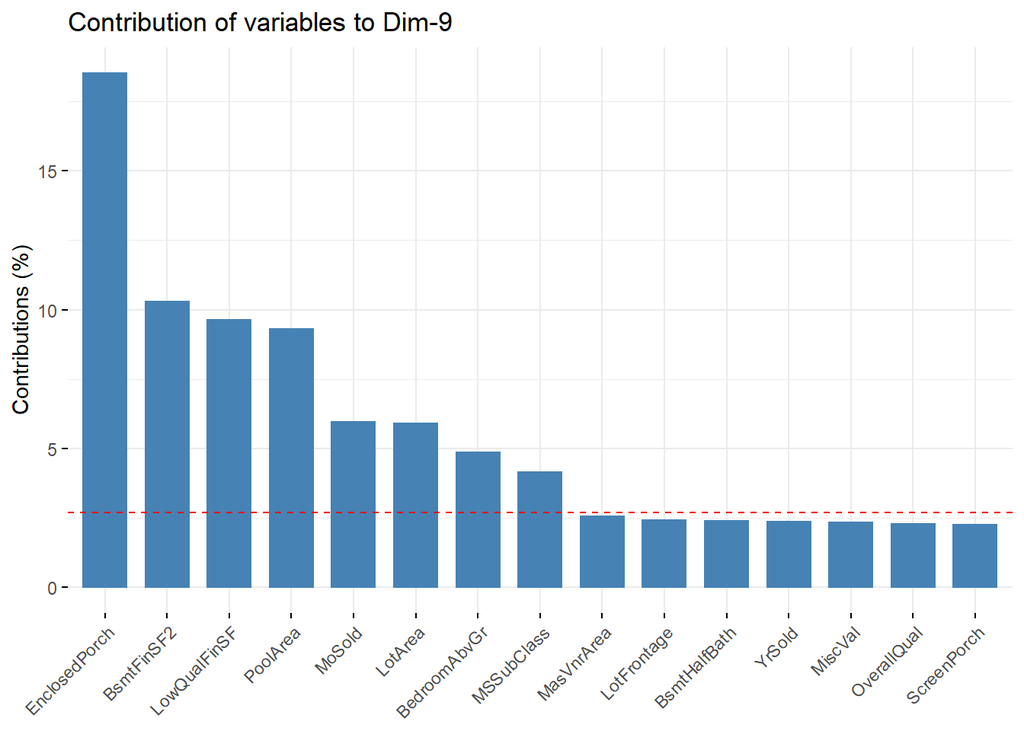

En este caso, el componente parece estar representado por variables que que aportan a la clase de construcción, como el tipo de pórtico, sótano (en relación con la calidad), piscina, cuartos y área neta de la casa. Adicionalmente se puede relacionar a la representatividad que tiene en los meses que es comprada.

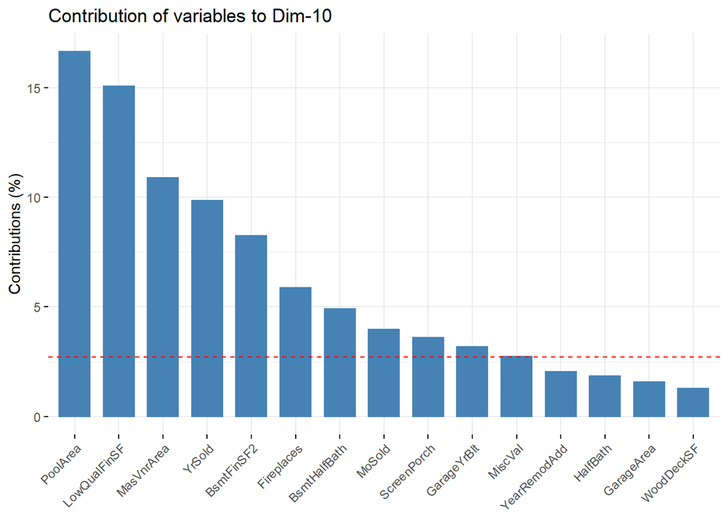

En la 10ma dimensión tenemos la presencia de variables que representan (en su mayoría) comodidades extras (como en alguno de los componentes anteriores). Tales como una gran área de piscina, tamaño (área) del sótano (por lo tanto presencia de otras características como baño), pórtico (tamaño también) y chimeneas.

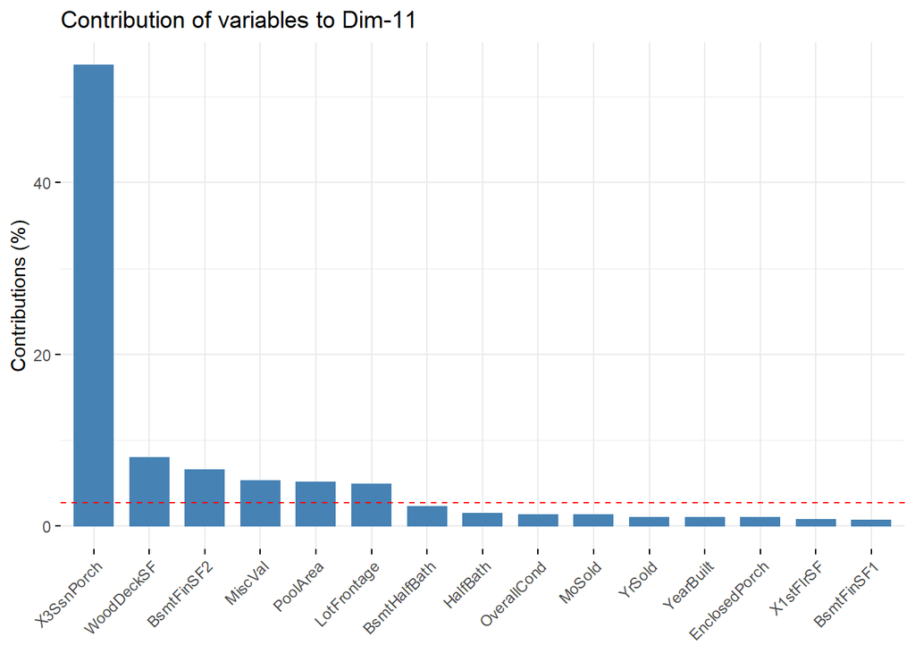

En esta dimensión hay un variable que tiene gran represantitividad (area en pies del pórtico de 3 estaciones) que generalmente se encuentra en casas grandes, por lo que de cierta manera tenemos otras que aportan al tamaño tales como: área del deck, área del sótano, área de la piscina y miscelaneos (agregan valor)

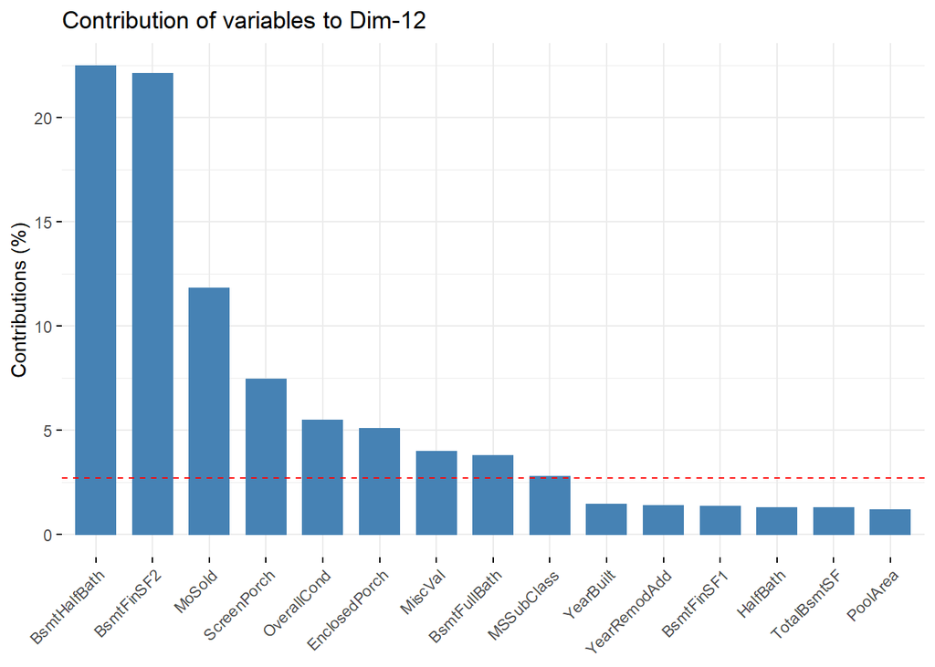

En esta dimensión tenemos dos variables que tienen casí la misma contribución, baños medios del sótano y áreas terminadas del sótano (en menor contribución hay baños completos del sótano), por lo que la relación parece ser algo evidente al comienzo, sin embargo luego tenemos mes de venta, pórtico, condición general.

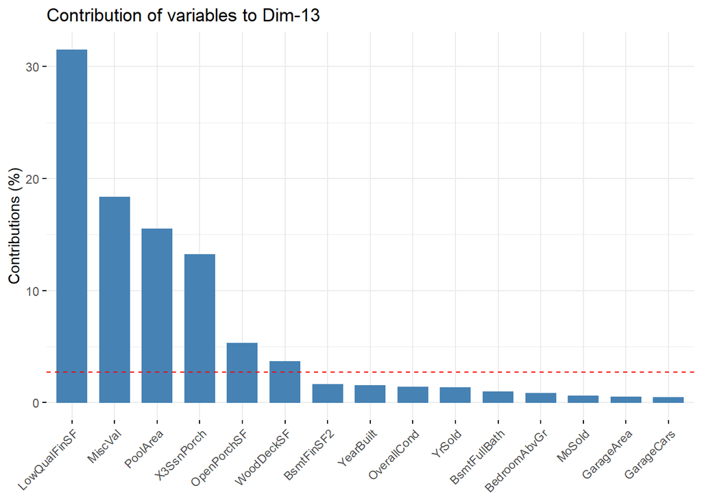

En este componente se tienen 6 variables sobre el límite en donde todas, excepto MiscVal hacen referencia al área de diferentes partes del hogar como la planta baja, piscina,diferentes pórticos. Siendo MiscVal el valor de características extras se puede inferir que se debe a que estas casas (mayormente) al tener todas estas variables, tienden a tener presente otras características miscelaneas

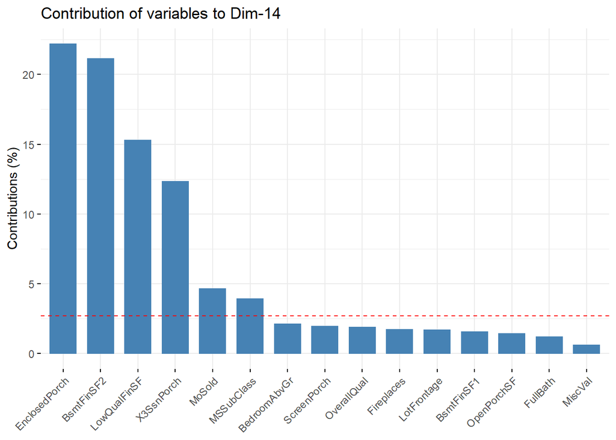

En el componente 14 se tienen 4 variables que hacen referencia al tamaño del pórtico, sótano, planta baja o pórtico de 3 estaciones. Las otras dos son de clase de construcción y el mes en el que fueron compradas, por lo que puede existir una relación entre el tamaño de características extra que (definitivamente) afecta la lase de construcción y se encuentra relacionada de alguna manera a algún mes en específico en donde hay más probabilidad de ser comprada.

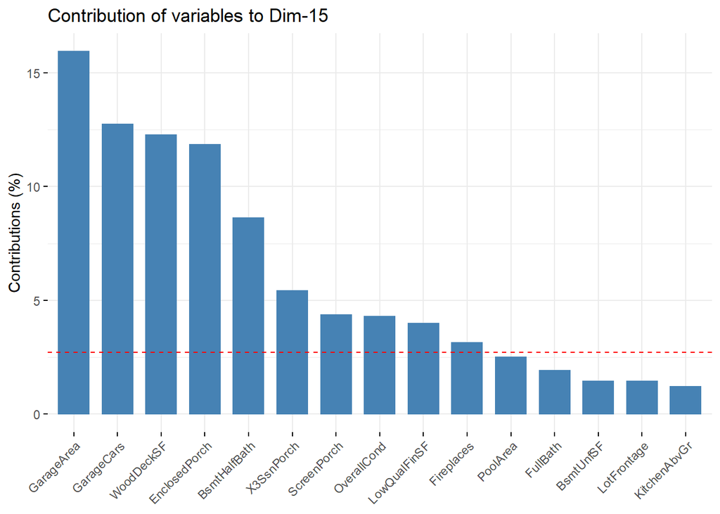

En la 15 dimensión tenemos las variables que hacen alusión a áreas extra del hogar que de estar presentes tienen una relación con la calidad general de la casa.

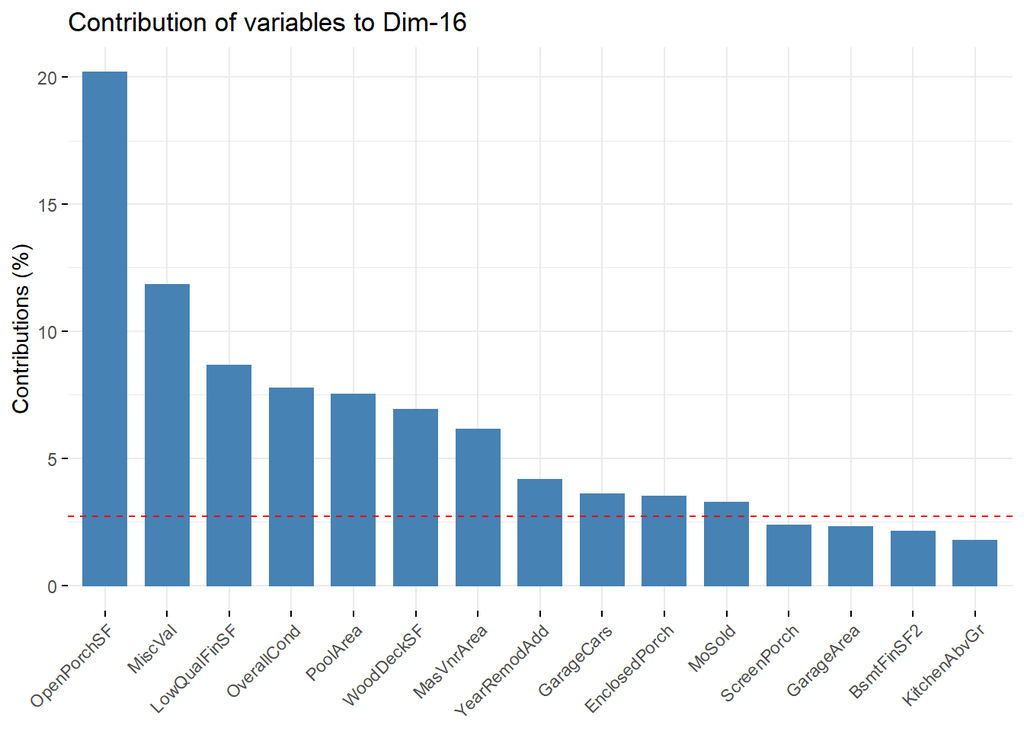

En el componente 16 hay varias variables que se encuentran sobre el límite y por lo tanto dificilmente hay una relación muy particular entre todas, hay variables que describen el área, o el año en el que fue remodelado (mejorando o añadiendo probablemente), por lo que de cierta manera se puede atar con la calidad general de la casa con base en varias características.

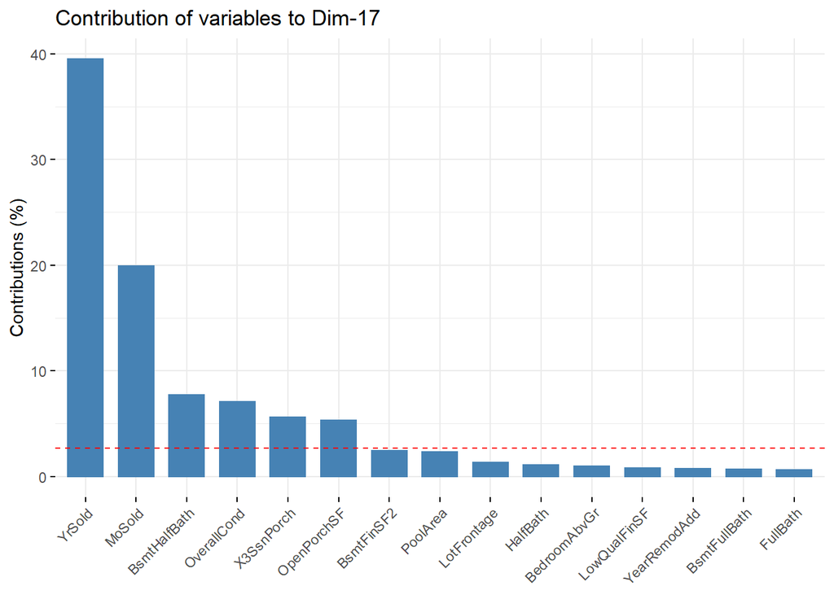

En esta última componente podemos ver 6 variables sobre el límite de contribución en donde los que más aportan son las variables del año y el mes que fueron vendidos, por lo que las demás condiciones; baño en e sótano, codición general, área de pórtico de 3 estaciones y área de pórtico abierto. Pueden ser características que tienen más probabilidad de ser llamativas en un año en particular o mes (como estaciones del año).

## Reglas de Asociación

Se trabajará únicamente con las variables categóricas ya que para trabajar con las cuantitativas se necesitaría discretizar los datos, para lo que es necesario saber en qué rango deberían encontrarse los valores. Para esto, las variables se convertirán primero en factores y luego ya que determinará la cantidad de reglas de asociación con 0.2 de soporte y 0.7 de confianza para tener tanto un soporte como un nivel de confianza manejables y no tan estrictos.

```
## 'data.frame':    1460 obs. of  81 variables:
##  $ Id           : int  1 2 3 4 5 6 7 8 9 10 ...
##  $ MSSubClass   : int  60 20 60 70 60 50 20 60 50 190 ...
##  $ MSZoning     : chr  "RL" "RL" "RL" "RL" ...
##  $ LotFrontage  : int  65 80 68 60 84 85 75 NA 51 50 ...
##  $ LotArea      : int  8450 9600 11250 9550 14260 14115 10084 10382 6120 7420 ...
##  $ Street       : chr  "Pave" "Pave" "Pave" "Pave" ...
##  $ Alley        : chr  NA NA NA NA ...
##  $ LotShape     : chr  "Reg" "Reg" "IR1" "IR1" ...
##  $ LandContour  : chr  "Lvl" "Lvl" "Lvl" "Lvl" ...
##  $ Utilities    : chr  "AllPub" "AllPub" "AllPub" "AllPub" ...
##  $ LotConfig    : chr  "Inside" "FR2" "Inside" "Corner" ...
##  $ LandSlope    : chr  "Gtl" "Gtl" "Gtl" "Gtl" ...
##  $ Neighborhood : chr  "CollgCr" "Veenker" "CollgCr" "Crawfor" ...
##  $ Condition1   : chr  "Norm" "Feedr" "Norm" "Norm" ...
```

[output cut: 67 more lines]

[output not shown]

[output cut: 46 more lines]

```
## Apriori
##
## Parameter specification:
##  confidence minval smax arem  aval originalSupport maxtime support minlen
##         0.7    0.1    1 none FALSE            TRUE       5     0.2      1
##  maxlen target  ext
##      10  rules TRUE
##
## Algorithmic control:
##  filter tree heap memopt load sort verbose
##     0.1 TRUE TRUE  FALSE TRUE    2    TRUE
##
## Absolute minimum support count: 292
##
## set item appearances ...[0 item(s)] done [0.00s].
## set transactions ...[87 item(s), 1460 transaction(s)] done [0.00s].
## sorting and recoding items ... [83 item(s)] done [0.00s].
## creating transaction tree ... done [0.00s].
## checking subsets of size 1 2 3 4 5 6 7 8 9 10
```

```
##  done [4.49s].
## writing ... [5726880 rule(s)] done [1.08s].
## creating S4 object  ... done [3.08s].
```

Podemos observar que se han creado varias reglas de asociación, en algunos casos alrededor de 3 millones y en otros 5 millones. Estas logran identificar relaciones raras o imperceptibles a simple vista en nuestro set de datos, y, tomando en cuenta la gran cantidad de datos con los que se cuenta a pesar de haber trabajado únicamente con las variables categóricas, tiene sentido la cantidad de reglas que han sido generadas.

## Conclusiones

### Análisis exploratorio

En el set de datos utilizado se ha encontrado que se cuenta con un total de 81 variables, siendo 43 de tipo character y 38 de tipo integer, entre estas se encuentran algunas como el tamaño del lote, la cantidad de habitaciones, la cantidad de baños completos y medios baños, el estado de la cocina, o cocinas, y el estado del sótano, una de ellas es el id por lo que no ha sido utilizado para realizar los análisis necesarios. Se han encontrado datos interesantes tales como que el lote con mayor tamaño cuenta con más de 200,000 metros cuadrados y que, contradictoriamente a lo que podría imaginarse, no existe correlación entre el precio de la casa y el tamaño del lote pero sí existe correlación entre el año de construcción y el precio de esta, al igual que con la cantidad de metros cuadrados del sótano. También se han encontrado datos sobre los años en los que se ha construido la mayor cantidad de casas y la capacidad de un garage basado en la cantidad de carros que pueden ocuparlo.

### PCA

El análisis de componentes principales es muy útil al utilizar conjuntos de datos tan amplios como el set de datos de las casas (con 81 variables). Esto permite disminuir significativamente la cantidad de variables a utilizar y por lo tanto la demanda computacional disminuye. Se logró disminuir de 37 variables (númericas) a 17 a través del PCA, la cuál agrupó en dimensiones las variables significativas en cada componente, permitiendo interpretarla en base a sus relaciones específicas, como precio por comodidad, por tamaño, extensiones etc.